# Eviction Dashboard

Thomas Gao, Intern

Open Justice Oklahoma

2021-05-17

> **What are the top 10 evictors in Oklahoma’s top four most populous counties? (Tulsa, Oklahoma, Cleveland, Canadian)**

> **Approximately how many evictions were filed in each court from 2018-2019?** **Approximately how many different plaintiffs filed evictions in each court?** **What percentage of filers accounted for 50 percent of the evictions?**

# 1 Data sources

OSCN small claims database

## 1.1 Timeframe

Cases filed in 2018 and 2019

## 1.2 Geography

Oklahoma’s four most populous counties: - Oklahoma - Tulsa - Cleveland - Canadian Tulsa county, Oklahoma county, maybe Cleveland and Canadian county

## 1.3 Variables

What variables did you use? What types of cases, crimes, etc.? iss_description Forcible entry and detainer ## Query

If you’re using data from the OJO database, include the query you used to pull your data. This may be a function that starts `ojo_query_` or `dbGetQuery`. ###This step queries all the small claims court data from the 4 counties into a data frame

```r
okevic <- ojo_query_disps(c("TULSA", "OKLAHOMA", "CLEVELAND", "CANADIAN"), "SC", 2018:2019)
```

# 2 Checking Data

Explain the results of the checks of your data.

## 2.1 Check for Completeness

If you’re using court data, you can use the `ojo_check_comp` to see how complete the data is. ###this step checks the completeness of the data

```r
#ojo_check_comp(okevic)
```

## 2.2 Check for NAs

Detail the NAs and blank items in your data and, if necessary and possible, fill them in. ###this step filters out the dispositions without a defendant name

```r
nas <- okevic %>%
  group_by(casenum) %>%
  filter(all(is.na(defname)| defname ==""))
```

## 2.3 Check for outliers

If you’re looking at numeric data, look at the highest and lowest values and explain your procedures to deal with them in this section.

# 3 Defining Measures

This is where you’ll likely spend the biggest chunk of time if you’re using court data. There are a lot of ways things can go wrong, so we want to be able to trace back all of our steps and document all the decisions we’re making.

Because each analysis project is a bit different, the number and length of subsections in this section will vary a lot. ### this step will give us a list of issues filed in the small claims courts

```r
okevic %>%
  count(iss_desc) %>%
  arrange(desc(n))
```

```
##                                 iss_desc     n
## 1              FORCIBLE ENTRY & DETAINER 93215
## 2                           INDEBTEDNESS 45342
## 3                        PROMISSORY NOTE 12923
## 4                INDEBTEDNESS >$5000.00.  4410
## 5   FORCIBLE ENTRY & DETAINER >$5000.00.   760
## 6             PROMISSORY NOTE >$5000.00.   270
## 7                 AFFIDAVIT FOR REPLEVIN   250
## 8                                DAMAGES   239
## 9            BREACH AGREEMENT - CONTRACT   236
## 10 BREACH AGREEMENT - CONTRACT>$5000.00.   218
## 11                     DAMAGES >$5000.00   135
## 12     AFFIDAVIT FOR REPLEVIN >$5000.00.    74
## 13                          INTERPLEADER    38
## 14                    ABANDONED PROPERTY    32
## 15      AUTOMOBILE NEGLIGENCE >$5000.00.    14
## 16                 AUTOMOBILE NEGLIGENCE    13
## 17                                           9
## 18                          COUNTERCLAIM     8
## 19                  NEGLIGENCE >$5000.00     5
## 20                            NEGLIGENCE     4
## 21                COUNTERCLAIM OR SETOFF     3
## 22               COUNTER CLAIM OR SETOFF     2
## 23                                 OTHER     2
## 24          ABANDONED PROPERTY >$5000.00     1
## 25                       AUTO NEGLIGENCE     1
## 26   FORFEITURE OF CONTRABAND >$5000.00.     1
## 27                         FRIENDLY SUIT     1
## 28              OTHER - CIVIL NO DAMAGES     1
```

```r
### this step filters out only the eviction cases from the data frame

okevict <- okevic %>%
  filter(str_detect(iss_desc, "FORCI"))

okevict %>%
  count(iss_plaint) %>%
  arrange(desc(n))
```

```
##                                              iss_plaint    n
## 1                                                       9718
## 2                                COBBLESTONE APARTMENTS 1118
## 3                 CASCADES AT SOUTHERN HILLS APARTMENTS  780
## 4                     SOMERSET PARK AT UNION APARTMENTS  675
## 5                   VISTA AT SHADOW MOUNTAIN APARTMENTS  599
## 6                              LINCOLN GLENS APARTMENTS  586
## 7                          HUNTINGTON HOLLOW APARTMENTS  533
## 8                                   THE GREENS ON ASPEN  512
## 9                                 RIVERCHASE APARTMENTS  460
## 10                         GREENS OF BEDFORD APARTMENTS  443
## 11                                 SHORELINE APARTMENTS  442
## 12                           QUAIL RIDGE APARTMENTS LLC  438
## 13                               PARK VILLAS APARTMENTS  412
## 14                                 RED RIVER APARTMENTS  394
```

[output cut: 9977 more lines]

```r
### this step changed the data frame from dispositions to actual cases by only saving one casenumber for each disposition

okevict <- okevict %>%
  group_by(court, casenum) %>%
  slice(1)
```

### 3.0.1 Fill plaintiff names for Cleveland County

```r
cleve <- okevict %>%
  filter(court == "CLEVELAND") %>%
  select(-iss_plaint)

connect_ojo()
cleve_plaints <- dbGetQuery(ojo_db, "SELECT *
                            FROM oscn_party_names
                            WHERE court = 'CLEVELAND'
                            AND file_year > 2017
                            AND casetype = 'SC'")
disconnect_ojo()
```

```
## [[1]]
## [1] TRUE
```

```r
cleve_plaints <- cleve_plaints %>%
  filter(party_type == "Plaintiff") %>%
  group_by(court, casenum) %>%
  slice(1) %>%
  select(casenum, iss_plaint = party)
cleve <- cleve %>%
  left_join(cleve_plaints)
okevict <- okevict %>%
  filter(!court == "CLEVELAND") %>%
  bind_rows(cleve)
```

Describe what you’re looking for in each of these chunks

How many cases were filed in each court, 2018-2019?

This step gives us a break down of how many evictions were filed in each court from 2018-2019?

```r
year <- okevict %>%
  ungroup %>%
  count(court)

year
```

```
## # A tibble: 4 x 2
##   court         n
##   <chr>     <int>
## 1 CANADIAN   1463
## 2 CLEVELAND  7491
## 3 OKLAHOMA  28925
## 4 TULSA     28981
```

```r
plaintiff <- okevict %>%
  ungroup %>%
  count(court, iss_plaint) %>%
  arrange(desc(n))

plaintiff
```

```
## # A tibble: 11,418 x 3
##    court     iss_plaint                                n
##    <chr>     <chr>                                 <int>
##  1 CLEVELAND BROOKWOOD VILLAGE APARTMENTS LLC        789
##  2 TULSA     COBBLESTONE APARTMENTS                  678
##  3 TULSA     SOMERSET PARK AT UNION APARTMENTS       520
##  4 TULSA     CASCADES AT SOUTHERN HILLS APARTMENTS   449
##  5 CLEVELAND COUNTRY CREEK                           436
##  6 TULSA     VISTA AT SHADOW MOUNTAIN APARTMENTS     370
##  7 TULSA     LINCOLN GLENS APARTMENTS                368
##  8 TULSA     HUNTINGTON HOLLOW APARTMENTS            358
##  9 OKLAHOMA  QUAIL RIDGE APARTMENTS LLC              330
## 10 OKLAHOMA  OAKWOOD PROPERTY MGMT LLC               320
## # … with 11,408 more rows
```

This step gives us who are the top 10 evictors in Oklahoma’s top four most populous counties by cleaning the plaintiff names and counting how many cases they have filed and the data frame is then arranged in a descending order

```r
tulsa <- okevict %>%
  filter(court == "TULSA") %>%
  mutate(plaint_clean = windex(iss_plaint))

tulsacount <- tulsa %>%
  ungroup %>%
  count(court, plaint_clean) %>%
  arrange(desc(n)) %>%
  group_by(court)

oklahoma <- okevict %>%
  filter(court == "OKLAHOMA") %>%
  mutate(plaint_clean = windex(iss_plaint))

oklahomacount <- oklahoma %>%
  ungroup %>%
  count(court, plaint_clean) %>%
  arrange(desc(n)) %>%
  group_by(court)

cleveland <- okevict %>%
  filter(court == "CLEVELAND") %>%
  mutate(plaint_clean = windex_cleve(iss_plaint))

clevelandcount <- cleveland %>%
  ungroup %>%
  count(court, plaint_clean) %>%
  arrange(desc(n)) %>%
  group_by(court)


canadian <- okevict %>%
  filter(court == "CANADIAN") %>%
  mutate(plaint_clean = windex(iss_plaint))

canadiancount <- canadian %>%
  ungroup %>%
  count(court, plaint_clean) %>%
  arrange(desc(n)) %>%
  group_by(court)
```

### 3.0.2 this step calculates what percentage of evictors accounted for 50% of all eviction filings

```r
tulsacount
```

```
## # A tibble: 3,019 x 3
## # Groups:   court [1]
##    court plaint_clean                           n
##    <chr> <chr>                              <int>
##  1 TULSA COBBLESTONE APARTMENTS               706
##  2 TULSA VISTA SHADOW MOUNTAIN APARTMENTS     570
##  3 TULSA SOMERSET PARK UNION APARTMENTS       550
##  4 TULSA CASCADES SOUTHERN HILLS APARTMENTS   449
##  5 TULSA GREENS OWASSO                        409
##  6 TULSA HUNTINGTON HOLLOW APARTMENTS         377
##  7 TULSA LINCOLN GLENS APARTMENTS             377
##  8 TULSA LONDON SQUARE APARTMENTS             342
##  9 TULSA GREENS BROKEN ARROW                  304
## 10 TULSA RIVERCHASE APARTMENTS                303
## # … with 3,009 more rows
```

```r
sum(tulsacount$n)/2
```

```
## [1] 14490.5
```

```r
tulsacount <- tulsacount %>%
  mutate(rank = row_number(),
        rolling_sum = cumsum(n))

totalcount1 <- merge(tulsacount, oklahomacount, by = c("court", "plaint_clean", "n"))
totalcount2 <- rbind(tulsacount, oklahomacount)
totalcount <- rbind(tulsacount, oklahomacount, clevelandcount, canadiancount)
sum(totalcount$n)/2
```

```
## [1] 33430
```

```r
totalcount <- totalcount %>%
  ungroup %>%
  arrange(desc(n)) %>%
   mutate(rank = row_number(),
        rolling_sum = cumsum(n))
```

## 3.1 Graph portion of evictions filed by top evictors

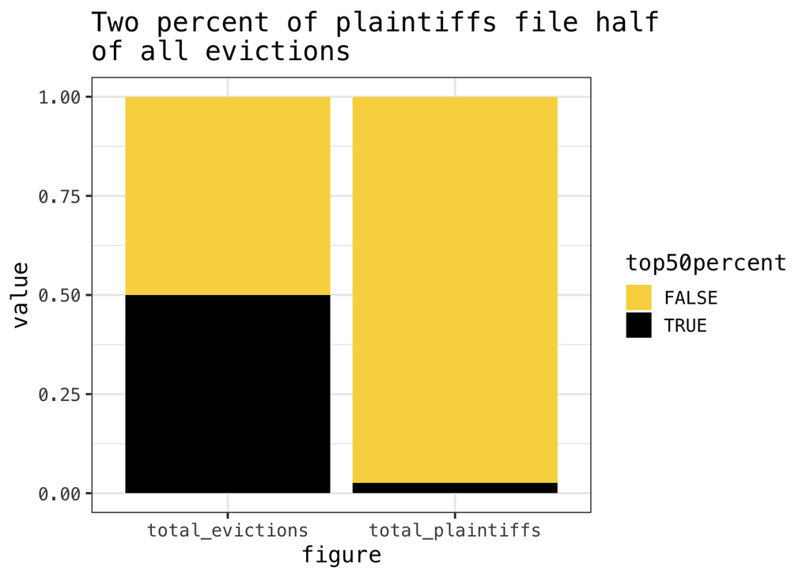

```r
top_evictor <- totalcount %>%
  mutate(top50percent = rank <= 240) %>%
  group_by(top50percent) %>%
  summarize(total_plaintiffs = n(),
            total_evictions = sum(n)) %>%
  pivot_longer(cols = matches("total"),
               names_to = "figure")

ggplot(top_evictor, aes(figure, value, fill = top50percent)) +
  geom_bar(stat = "identity", position = "fill") +
  theme_ojo() +
  scale_fill_manual(values = ojo_pal) +
  ggtitle("Two percent of plaintiffs file half\nof all evictions")
```

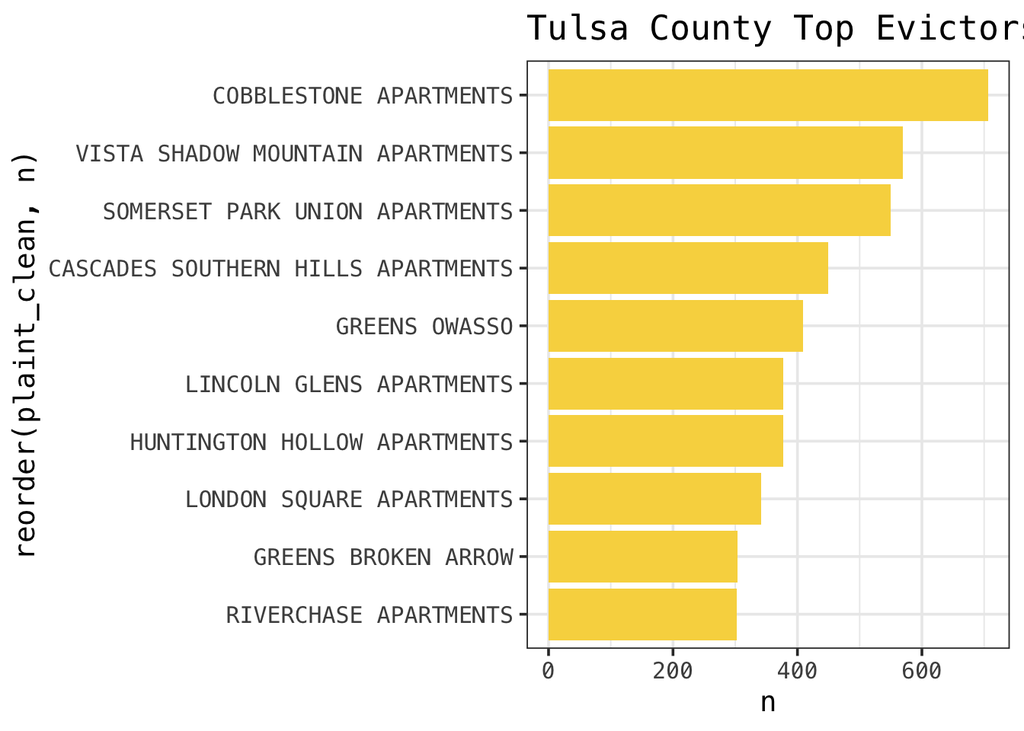

```r
tulsatop <- tulsacount %>%
  slice(1:10)
ggplot(tulsatop, aes(x=reorder(plaint_clean, n), y=n))+
  geom_bar(stat = "identity", fill ="#F8D64E") +
  theme_ojo() +
  scale_fill_manual(values = ojo_pal) +
  ggtitle("Tulsa County Top Evictors")+
  coord_flip()
```

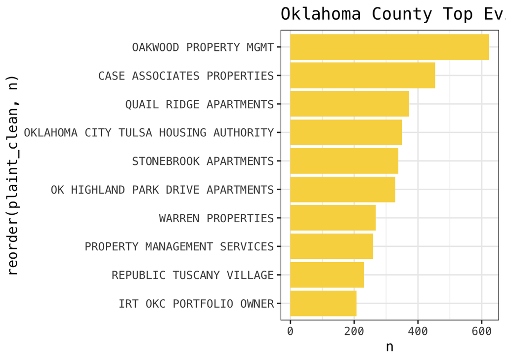

```r
oklahomatop <- oklahomacount %>%
  slice(1:10)
ggplot(oklahomatop, aes(x=reorder(plaint_clean, n), y=n))+
  geom_bar(stat = "identity", fill ="#F8D64E") +
  theme_ojo() +
  scale_fill_manual(values = ojo_pal) +
  ggtitle("Oklahoma County Top Evictors")+
  coord_flip()
```

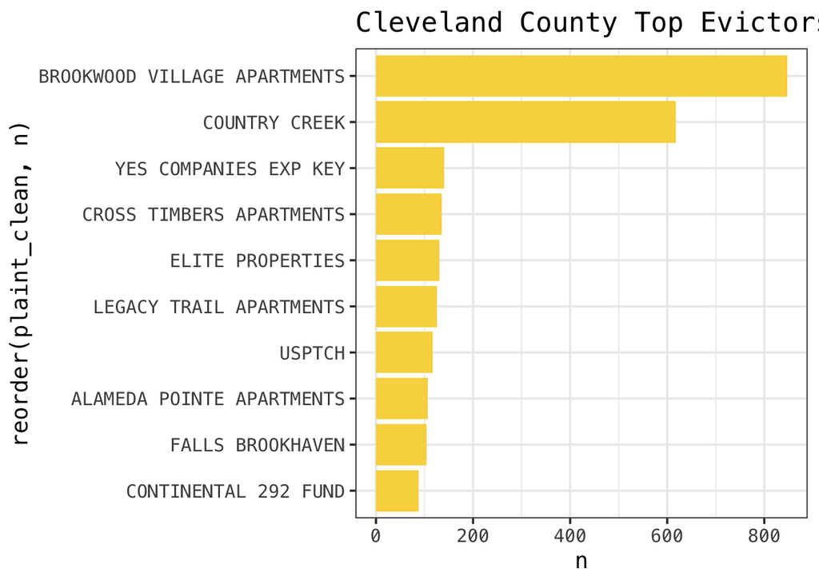

```r
clevelandtop <- clevelandcount %>%
  slice(1:10)
ggplot(clevelandtop, aes(x=reorder(plaint_clean, n), y=n))+
  geom_bar(stat = "identity", fill ="#F8D64E") +
  theme_ojo() +
  scale_fill_manual(values = ojo_pal) +
  ggtitle("Cleveland County Top Evictors")+
  coord_flip()
```

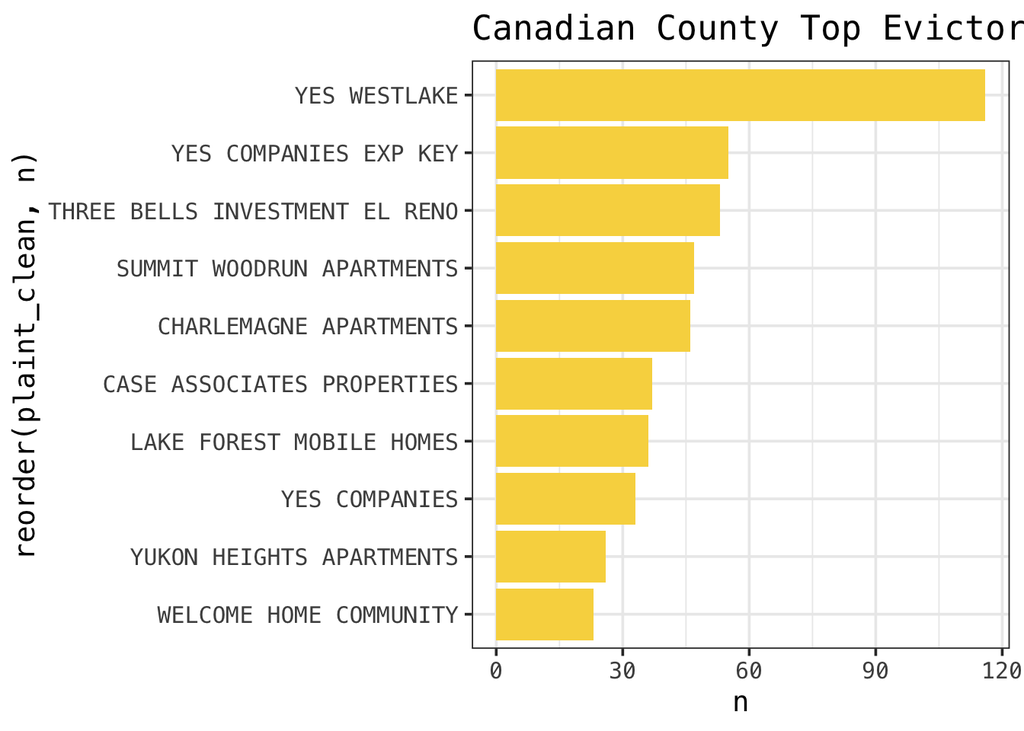

```r
canadiantop <- canadiancount %>%
  slice(1:10)
ggplot(canadiantop, aes(x=reorder(plaint_clean, n), y=n))+
  geom_bar(stat = "identity", fill ="#F8D64E") +
  theme_ojo() +
  scale_fill_manual(values = ojo_pal) +
  ggtitle("Canadian County Top Evictors")+
  coord_flip()
```

# 4 Summarizing and Visualizing Data

There will likely be several sections here too. Summarize and visualize the data in different ways and identify trends that you see.